# Using ABACAB and KU-UNC as example for analyses discussed in 525

Eric Youngstrom, PhD

Spring Semester 2023

# Overview

This notebook has a bunch of worked examples for different visualizations (especially in Exploratory Data Analysis mode) and statistical analyses.

You will definitely not need all of these for your project, and you may need or want some other things that are not covered in these examples.

A typical student project would use a subset of these chunks, with this sequence as a common work flow:

1. library to load your packages (haven, psych, ggplot, tidyverse, etc.)
2. load your data (usually haven for us)
3. select your variables (look at the modelvars example; remember to include age and sex, maybe race as ways of describing participants)
4. psych::describe to get the descriptives (N, min, max, M, SD, skew, kurtosis)
5. pairs.panels – are the relationships linear? Do the histograms look okay? etc…
6. na.omit – get rid of missing data
7. run analysis (often setCor or lm)
8. make table or figure – could be ggplot, or could be the tricked out version of pairs.panels with the asterisks, etc. (code is in the class notes for today). That covers the bases for most people’s posters. Everything you need (unless you are running logistic regression or something else “off menu”) should be in the two notebooks, and usually all is in the second one.
9. Write out “sufficient data” for someone else to be able to replicate your results.

One way of organizing your final project would be to copy and paste the relevant chunks into a new notebook that you make for it. That will let you streamline things and customize it as you wish.

```r
library(tidyverse) #wrangling
```

```r
library(haven) #importing SPSS and other data formats
library(ggplot2) #deluxe graphics
library(ggExtra) #extra fancy graphics
library(psych) #one package that covers ~80% of what we use in psychology
library(rstatix) #a package that offers useful options for correlation tables, ANOVA
library(vcd) #visual displays of categorical data
library(mosaic) #more tools for categorical data
library(rockchalk) #useful for intermediate/advanced regression analyses
options(digits = 3, scipen = NULL)
knitr::opts_chunk$set(echo = TRUE)
```

Note: v3.2 of the data had an error in item 10 (it was accidentally over-written by the 10 item scale score)

```r
# [] come back to this and load the datasets for class
abacab <- read_sav("Ultimate Enchilada v3.3 chopped for 525 v4.sav")
ku2017<-read_spss("Korea_Spring_Fall_2017 v5 (safe)+2018+2019+Spr2020 April 2023 fix.sav")
```

```r
modelvars<-abacab %>%
  select(cmrsptot, pgbsleep, bpvsall, anyadhd, agechild, cgender, cgroup5)
#make data subset
```

# Checking assumptions

```r
describe(modelvars) #Get N, min & max (compare to source docs), skew & kurtosis
```

|  | vars | n | mean | sd | median | trimmed | mad | min | max | range | skew | kurtosis | se |
| --- | --- | --- | --- | --- | --- | --- | --- | --- | --- | --- | --- | --- | --- |
| cmrsptot | 1 | 542 | 15.521 | 10.599 | 14 | 14.525 | 10.38 | 0 | 55 | 55 | 0.8172 | 0.327 | 0.4553 |
| pgbsleep | 2 | 817 | 4.502 | 4.387 | 3 | 3.889 | 4.45 | 0 | 20 | 20 | 1.0386 | 0.502 | 0.1535 |
| bpvsall | 3 | 825 | 0.184 | 0.388 | 0 | 0.106 | 0.00 | 0 | 1 | 1 | 1.6260 | 0.645 | 0.0135 |
| anyadhd | 4 | 825 | 0.630 | 0.483 | 1 | 0.663 | 0.00 | 0 | 1 | 1 | -0.5389 | -1.712 | 0.0168 |
| agechild | 5 | 825 | 10.895 | 3.428 | 11 | 10.888 | 4.45 | 4 | 18 | 14 | -0.0373 | -1.049 | 0.1194 |
| cgender | 6 | 825 | 0.402 | 0.491 | 0 | 0.378 | 0.00 | 0 | 1 | 1 | 0.3972 | -1.844 | 0.0171 |
| cgroup5 | 7 | 825 | 3.405 | 0.970 | 4 | 3.440 | 1.48 | 1 | 5 | 4 | -0.5368 | -0.203 | 0.0338 |

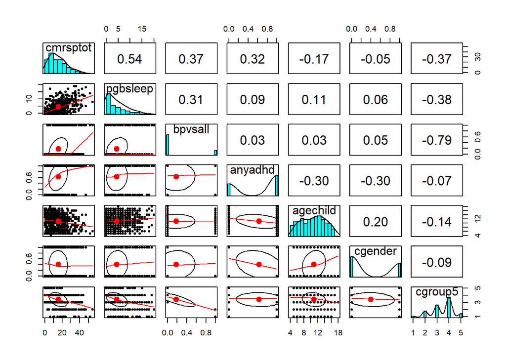

```r
pairs.panels(modelvars) #Look at histograms, scatterplots, LOESS smoother
```